# Homework 4 - A.Sauk

Alexandra Sauk

25/02/2020

## Q2 Variables and Hypotheses

I hypothesize that class affected passenger survival as different classes were located on different levels of ship leading to different distances from the life boats.

I hypothesize that age affected passenger survival, either in ability to reach the life boats or preferrential placement on the life boats.

I hypothesize that gender affected passenger survival, either in ability to reach the life boats or preferrential placement on the life boats.

I hypothesize that the number of parents and/or children on board affected passenger survival as those with relatives on board may have prioritized survival of relatives.

I hypothesize that fare price affected passenger survival as the fare price is related to the area of the ship that the passengers would be staying in changing their proximity to life boats and potential the damage to the hull.

## Q3 Mosaic plots of the relationship of categorical predictor variables with survival

```r
my.data<-read.csv("titanic.csv")
head(my.data)
```

```
##   pclass survived Residence                             name age sibsp parch
## 1      3        0         0              Abbing, Mr. Anthony  42     0     0
## 2      3        0         0    Abbott, Master. Eugene Joseph  13     0     2
## 3      3        0         0      Abbott, Mr. Rossmore Edward  16     1     1
## 4      3        1         0 Abbott, Mrs. Stanton (Rosa Hunt)  35     1     1
## 5      3        1         2      Abelseth, Miss. Karen Marie  16     0     0
## 6      3        1         0    Abelseth, Mr. Olaus Jorgensen  25     0     0
##      ticket  fare cabin embarked boat body              home.dest Gender
## 1 C.A. 5547  7.55              S        NA                             0
## 2 C.A. 2673 20.25              S        NA    East Providence, RI      0
## 3 C.A. 2673 20.25              S       190    East Providence, RI      0
## 4 C.A. 2673 20.25              S    A   NA    East Providence, RI      1
## 5    348125  7.65              S   16   NA Norway Los Angeles, CA      1
## 6    348122  7.65 F G63        S    A   NA     Perkins County, SD      0
```

```r
library("vcd")
```

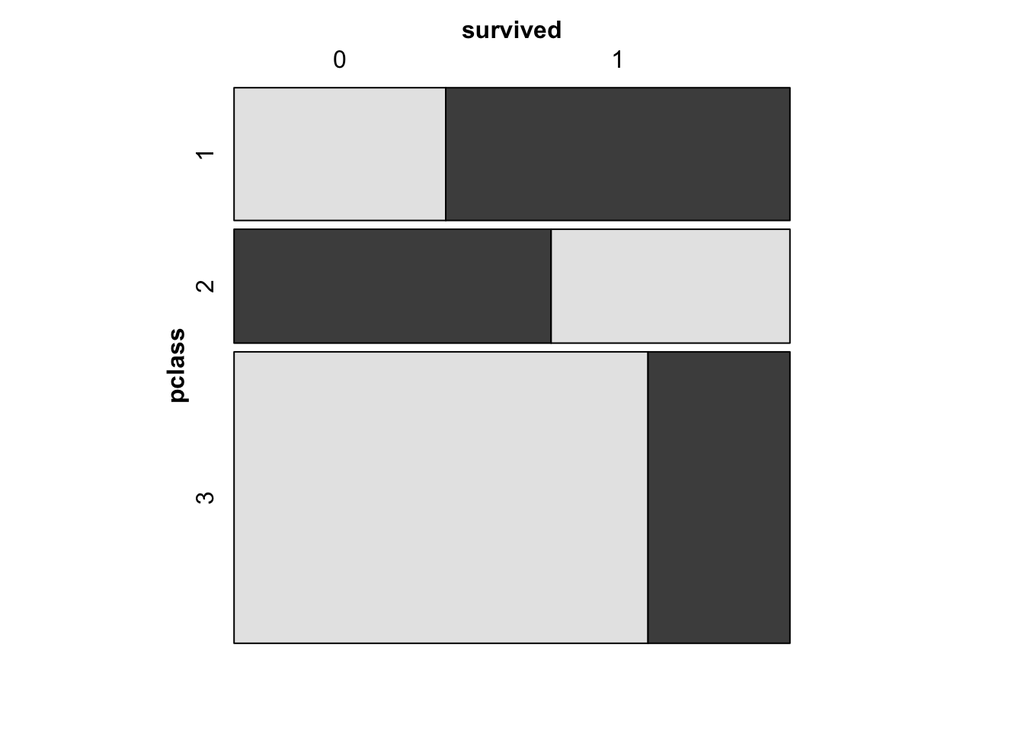

```r
mosaic(survived~pclass, data=my.data)
```

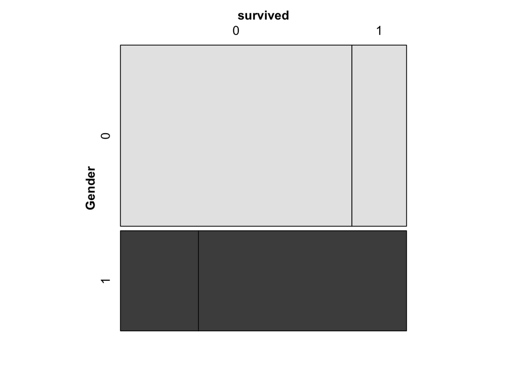

```r
mosaic(survived~Gender, data=my.data)
```

## Q3 logi.hist.plot of the relationship of continuous predictor variables with survival

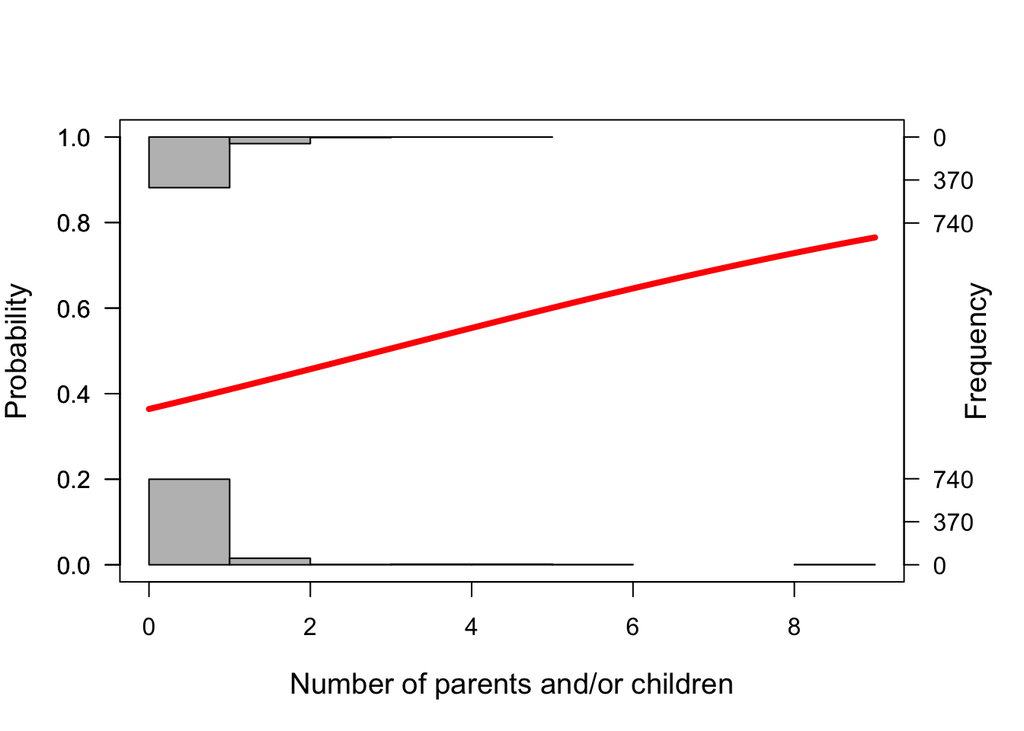

```r
library("popbio")

my.data.parch<-na.omit(data.frame("relatives"=my.data$parch, "survived"=my.data$survived))
logi.hist.plot(my.data.parch$relatives, my.data.parch$survived, boxp=FALSE, type="hist", col="grey", xlab="Number of parents and/or children")
```

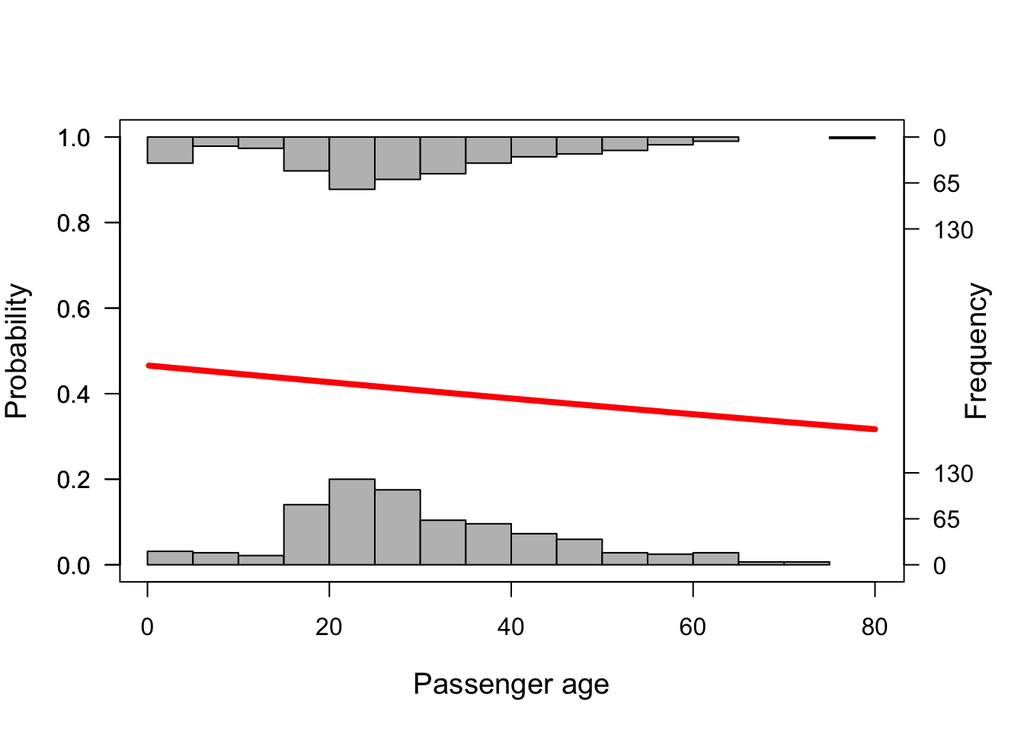

```r
my.data.age<-na.omit(data.frame("age"=my.data$age, "survived"=my.data$survived))
logi.hist.plot(my.data.age$age, my.data.age$survived, boxp=FALSE, type="hist", col="grey", xlab="Passenger age")
```

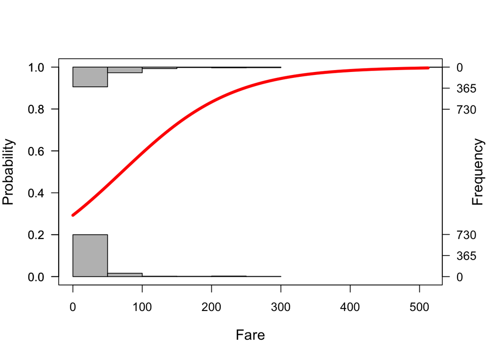

```r
my.data.fare<-na.omit(data.frame("fare"=my.data$fare, "survived"=my.data$survived))
logi.hist.plot(my.data.fare$fare, my.data.fare$survived, boxp=FALSE, type="hist", col="grey", xlab="Fare")
```

## Q4 Finding the best model

```r
library("bestglm")
my.variables=data.frame("age"=my.data$age,"fare"=my.data$fare,"relatives"=my.data$parch,"gender"=my.data$Gender,"class"=my.data$pclass,"survived"=my.data$survived)
my.variables.nona=na.omit(my.variables)
bestglm(my.variables.nona,IC="AIC",family=binomial)
```

```
## Morgan-Tatar search since family is non-gaussian.
```

```
## AIC
## BICq equivalent for q in (7.11598705571692e-06, 0.967192127262217)
## Best Model:
##                Estimate  Std. Error    z value     Pr(>|z|)
## (Intercept)  2.08911307 0.371597091   5.621984 1.887762e-08
## age         -0.03383281 0.006285196  -5.382937 7.328023e-08
## gender       2.49681121 0.166120258  15.030143 4.659998e-51
## class       -1.13245973 0.111779291 -10.131212 4.016384e-24
```

```r
model1<-glm(survived~age+gender+class, data=my.variables.nona)
summary.lm(model1)
```

```
##
## Call:
## glm(formula = survived ~ age + gender + class, data = my.variables.nona)
##
## Residuals:
##      Min       1Q   Median       3Q      Max
## -1.08371 -0.25794 -0.08018  0.21923  0.99805
##
## Coefficients:
##               Estimate Std. Error t value Pr(>|t|)
## (Intercept)  0.7855867  0.0574979  13.663  < 2e-16 ***
## age         -0.0052157  0.0009322  -5.595 2.82e-08 ***
## gender       0.4915299  0.0255628  19.228  < 2e-16 ***
## class       -0.1829774  0.0160760 -11.382  < 2e-16 ***
## ---
## Signif. codes:  0 '***' 0.001 '**' 0.01 '*' 0.05 '.' 0.1 ' ' 1
##
## Residual standard error: 0.3915 on 1041 degrees of freedom
## Multiple R-squared:  0.3682, Adjusted R-squared:  0.3664
## F-statistic: 202.2 on 3 and 1041 DF,  p-value: < 2.2e-16
```

## Q6 Purposeful selection

```r
univariate.gender=glm(survived~gender, data=my.variables.nona, family=binomial(link="logit"))
summary(univariate.gender)
```

```
##
## Call:
## glm(formula = survived ~ gender, family = binomial(link = "logit"),
##     data = my.variables.nona)
##
## Deviance Residuals:
##     Min       1Q   Median       3Q      Max
## -1.6713  -0.6783  -0.6783   0.7540   1.7790
##
## Coefficients:
##             Estimate Std. Error z value Pr(>|z|)
## (Intercept) -1.35239    0.09656  -14.01   <2e-16 ***
## gender       2.46480    0.15220   16.20   <2e-16 ***
## ---
## Signif. codes:  0 '***' 0.001 '**' 0.01 '*' 0.05 '.' 0.1 ' ' 1
##
## (Dispersion parameter for binomial family taken to be 1)
##
##     Null deviance: 1413.6  on 1044  degrees of freedom
## Residual deviance: 1101.5  on 1043  degrees of freedom
## AIC: 1105.5
##
## Number of Fisher Scoring iterations: 4
```

```r
univariate.fare=glm(survived~fare, data=my.variables.nona, family=binomial(link="logit"))
summary(univariate.fare)
```

```
##
## Call:
## glm(formula = survived ~ fare, family = binomial(link = "logit"),
##     data = my.variables.nona)
##
## Deviance Residuals:
##     Min       1Q   Median       3Q      Max
## -2.2308  -0.9284  -0.8981   1.3348   1.5278
##
## Coefficients:
##              Estimate Std. Error z value Pr(>|z|)
## (Intercept) -0.794094   0.084413  -9.407  < 2e-16 ***
## fare         0.012150   0.001704   7.132 9.92e-13 ***
## ---
## Signif. codes:  0 '***' 0.001 '**' 0.01 '*' 0.05 '.' 0.1 ' ' 1
##
## (Dispersion parameter for binomial family taken to be 1)
##
##     Null deviance: 1413.6  on 1044  degrees of freedom
## Residual deviance: 1339.9  on 1043  degrees of freedom
## AIC: 1343.9
##
## Number of Fisher Scoring iterations: 4
```

```r
univariate.relatives=glm(survived~relatives, data=my.variables.nona, family=binomial(link="logit"))
summary(univariate.relatives)
```

```
##
## Call:
## glm(formula = survived ~ relatives, family = binomial(link = "logit"),
##     data = my.variables.nona)
##
## Deviance Residuals:
##     Min       1Q   Median       3Q      Max
## -1.6952  -0.9784  -0.9784   1.3904   1.3904
##
## Coefficients:
##             Estimate Std. Error z value Pr(>|z|)
## (Intercept) -0.48799    0.07134  -6.841 7.88e-12 ***
## relatives    0.27556    0.07660   3.598 0.000321 ***
## ---
## Signif. codes:  0 '***' 0.001 '**' 0.01 '*' 0.05 '.' 0.1 ' ' 1
##
## (Dispersion parameter for binomial family taken to be 1)
##
##     Null deviance: 1413.6  on 1044  degrees of freedom
## Residual deviance: 1400.1  on 1043  degrees of freedom
## AIC: 1404.1
##
## Number of Fisher Scoring iterations: 4
```

```r
univariate.class=glm(survived~class, data=my.variables.nona, family=binomial(link="logit"))
summary(univariate.class)
```

```
##
## Call:
## glm(formula = survived ~ class, family = binomial(link = "logit"),
##     data = my.variables.nona)
##
## Deviance Residuals:
##     Min       1Q   Median       3Q      Max
## -1.4238  -0.7793  -0.7793   0.9496   1.6370
##
## Coefficients:
##             Estimate Std. Error z value Pr(>|z|)
## (Intercept)  1.36234    0.18247   7.466 8.25e-14 ***
## class       -0.79953    0.07954 -10.052  < 2e-16 ***
## ---
## Signif. codes:  0 '***' 0.001 '**' 0.01 '*' 0.05 '.' 0.1 ' ' 1
##
## (Dispersion parameter for binomial family taken to be 1)
##
##     Null deviance: 1413.6  on 1044  degrees of freedom
## Residual deviance: 1305.3  on 1043  degrees of freedom
## AIC: 1309.3
##
## Number of Fisher Scoring iterations: 4
```

```r
univariate.age=glm(survived~age, data=my.variables.nona, family=binomial(link="logit"))
summary(univariate.age)
```

```
##
## Call:
## glm(formula = survived ~ age, family = binomial(link = "logit"),
##     data = my.variables.nona)
##
## Deviance Residuals:
##     Min       1Q   Median       3Q      Max
## -1.1169  -1.0364  -0.9787   1.3186   1.5108
##
## Coefficients:
##              Estimate Std. Error z value Pr(>|z|)
## (Intercept) -0.141394   0.144839  -0.976   0.3290
## age         -0.007687   0.004414  -1.742   0.0816 .
## ---
## Signif. codes:  0 '***' 0.001 '**' 0.01 '*' 0.05 '.' 0.1 ' ' 1
##
## (Dispersion parameter for binomial family taken to be 1)
##
##     Null deviance: 1413.6  on 1044  degrees of freedom
## Residual deviance: 1410.5  on 1043  degrees of freedom
## AIC: 1414.5
##
## Number of Fisher Scoring iterations: 4
```

```r
##all variables with p<0.25

model2<-glm(survived~age+gender+class+fare+relatives, data=my.variables.nona)
summary.lm(model2)
```

```
##
## Call:
## glm(formula = survived ~ age + gender + class + fare + relatives,
##     data = my.variables.nona)
##
## Residuals:
##      Min       1Q   Median       3Q      Max
## -1.08299 -0.25581 -0.08336  0.22643  0.99546
##
## Coefficients:
##               Estimate Std. Error t value Pr(>|t|)
## (Intercept)  0.7717639  0.0660124  11.691   <2e-16 ***
## age         -0.0052559  0.0009412  -5.584    3e-08 ***
## gender       0.4928080  0.0262249  18.792   <2e-16 ***
## class       -0.1773103  0.0191363  -9.266   <2e-16 ***
## fare         0.0001521  0.0002751   0.553    0.580
## relatives   -0.0084074  0.0154355  -0.545    0.586
## ---
## Signif. codes:  0 '***' 0.001 '**' 0.01 '*' 0.05 '.' 0.1 ' ' 1
##
## Residual standard error: 0.3918 on 1039 degrees of freedom
## Multiple R-squared:  0.3685, Adjusted R-squared:  0.3654
## F-statistic: 121.2 on 5 and 1039 DF,  p-value: < 2.2e-16
```

```r
##simple model without relatives and fare
model3<-glm(survived~age+gender+class, data=my.variables.nona)
summary.lm(model3)
```

```
##
## Call:
## glm(formula = survived ~ age + gender + class, data = my.variables.nona)
##
## Residuals:
##      Min       1Q   Median       3Q      Max
## -1.08371 -0.25794 -0.08018  0.21923  0.99805
##
## Coefficients:
##               Estimate Std. Error t value Pr(>|t|)
## (Intercept)  0.7855867  0.0574979  13.663  < 2e-16 ***
## age         -0.0052157  0.0009322  -5.595 2.82e-08 ***
## gender       0.4915299  0.0255628  19.228  < 2e-16 ***
## class       -0.1829774  0.0160760 -11.382  < 2e-16 ***
## ---
## Signif. codes:  0 '***' 0.001 '**' 0.01 '*' 0.05 '.' 0.1 ' ' 1
##
## Residual standard error: 0.3915 on 1041 degrees of freedom
## Multiple R-squared:  0.3682, Adjusted R-squared:  0.3664
## F-statistic: 202.2 on 3 and 1041 DF,  p-value: < 2.2e-16
```

```r
##compare models
library("lmtest")
lrtest(model2,model3)
```

```
## Likelihood ratio test
##
## Model 1: survived ~ age + gender + class + fare + relatives
## Model 2: survived ~ age + gender + class
##   #Df  LogLik Df  Chisq Pr(>Chisq)
## 1   7 -500.54
## 2   5 -500.78 -2 0.4849     0.7847
```

## Q7 Compare automatic and purposeful selection

In this case, the automatic and purposeful selection of models resulted in the same best model with the variables of passenger age, gender, and class.

## Q8 Variable effects

```r
library("effects")
```

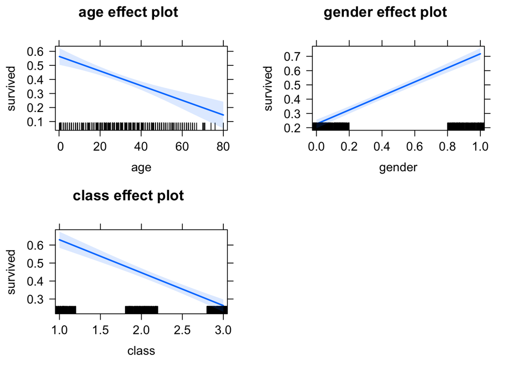

```r
plot(allEffects(model1))
```

All of the effects are in the direction that I expected, however, I was not expecting as large of a difference in male and female passenger survival. The variability in survival by age is surprising in that there is a some variability in the survival of children, little variablility for those between 20 and 40, and then variablility in surival increases with age after 40.

## Q9 test model assumptions

```r
library("car")
```

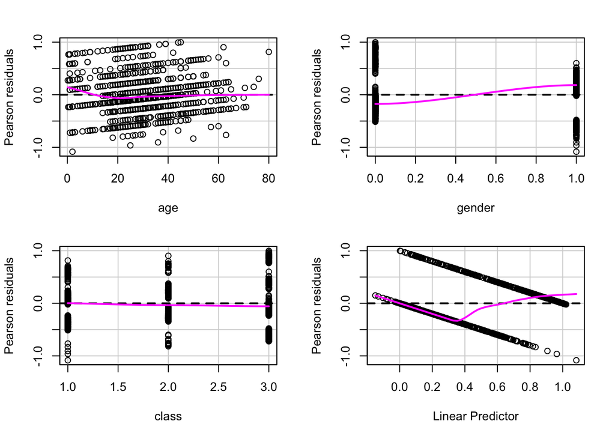

```
##        Test stat Pr(>|Test stat|)
## age       0.3609           0.5480
## gender    0.0000           1.0000
## class     0.1303           0.7181
```

```r
residualPlots(model1)
```

```r
outlierTest(model1)
```

```
## No Studentized residuals with Bonferroni p < 0.05
## Largest |rstudent|:
##     rstudent unadjusted p-value Bonferroni p
## 25 -2.792323          0.0052331           NA
```

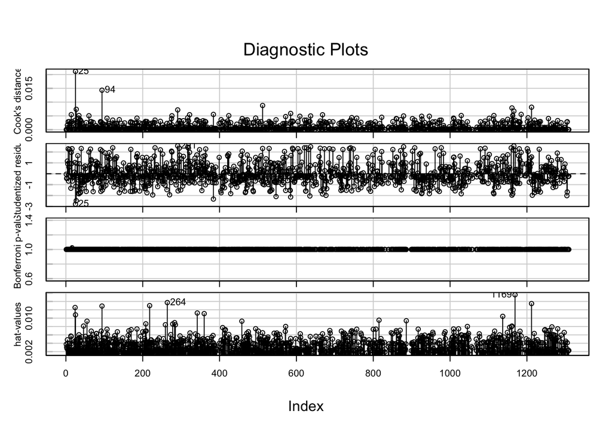

```r
influenceIndexPlot(model1, id.n=3)
```

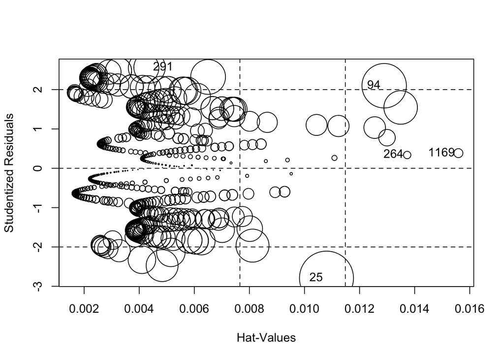

```
##         StudRes         Hat        CookD
## 25   -2.7923229 0.010799099 0.0211420873
## 94    2.0978766 0.012894099 0.0143255252
## 264   0.3369408 0.013729397 0.0003954327
## 291   2.5618051 0.004376314 0.0071734951
## 1169  0.3842430 0.015588639 0.0005849776
```

```r
influencePlot(model1)
```

```r
vif(model1)
```

```
##      age   gender    class
## 1.225582 1.040067 1.246724
```

## Q10 Results of regression diagnostics

The residuals seem to relatively evenly distributed without obvious skews or outliers such that the model appears to fit the data well. There is some potential the model is overestimating survival for male passengers and under estimating survival for female passengers based on the differences in the residuals for gender.

## Q11 k-fold cross validation

```r
library(caret)
library(e1071)
ctrl <- trainControl(method = "repeatedcv", number = 10, savePredictions = TRUE)
my.variables.nona$survived=as.factor(my.variables.nona$survived)
train(survived~age+gender+class,data=my.variables.nona, method="glm", family=binomial(link='logit'),
                 trControl = ctrl, tuneLength = 5)
```

```
## Generalized Linear Model
##
## 1045 samples
##    3 predictor
##    2 classes: '0', '1'
##
## No pre-processing
## Resampling: Cross-Validated (10 fold, repeated 1 times)
## Summary of sample sizes: 940, 940, 941, 940, 942, 940, ...
## Resampling results:
##
##   Accuracy   Kappa
##   0.7846666  0.5486732
```

## Q13 Confusion matrix

```r
predictions<-predict(model1, newdata=my.variables.nona, type = "response")
confusionMatrix(data=as.factor(as.numeric(predictions>0.5)),reference=as.factor(my.variables.nona$survived))
```

```
## Confusion Matrix and Statistics
##
##           Reference
## Prediction   0   1
##          0 523 133
##          1  95 294
##
##                Accuracy : 0.7818
##                  95% CI : (0.7555, 0.8065)
##     No Information Rate : 0.5914
##     P-Value [Acc > NIR] : < 2e-16
##
##                   Kappa : 0.5423
##
##  Mcnemar's Test P-Value : 0.01427
##
##             Sensitivity : 0.8463
##             Specificity : 0.6885
##          Pos Pred Value : 0.7973
##          Neg Pred Value : 0.7558
##              Prevalence : 0.5914
##          Detection Rate : 0.5005
##    Detection Prevalence : 0.6278
##       Balanced Accuracy : 0.7674
##
##        'Positive' Class : 0
##
```